# Project Foundations for Data Science: FoodHub Data Analysis

**Marks: 60**

### Context

The number of restaurants in New York is increasing day by day. Lots of students and busy professionals rely on those restaurants due to their hectic lifestyles. Online food delivery service is a great option for them. It provides them with good food from their favorite restaurants. A food aggregator company FoodHub offers access to multiple restaurants through a single smartphone app.

The app allows the restaurants to receive a direct online order from a customer. The app assigns a delivery person from the company to pick up the order after it is confirmed by the restaurant. The delivery person then uses the map to reach the restaurant and waits for the food package. Once the food package is handed over to the delivery person, he/she confirms the pick-up in the app and travels to the customer's location to deliver the food. The delivery person confirms the drop-off in the app after delivering the food package to the customer. The customer can rate the order in the app. The food aggregator earns money by collecting a fixed margin of the delivery order from the restaurants.

### Objective

The food aggregator company has stored the data of the different orders made by the registered customers in their online portal. They want to analyze the data to get a fair idea about the demand of different restaurants which will help them in enhancing their customer experience. Suppose you are hired as a Data Scientist in this company and the Data Science team has shared some of the key questions that need to be answered. Perform the data analysis to find answers to these questions that will help the company to improve the business.

### Data Description

The data contains the different data related to a food order. The detailed data dictionary is given below.

### Data Dictionary

- order_id: Unique ID of the order
- customer_id: ID of the customer who ordered the food
- restaurant_name: Name of the restaurant
- cuisine_type: Cuisine ordered by the customer
- cost: Cost of the order
- day_of_the_week: Indicates whether the order is placed on a weekday or weekend (The weekday is from Monday to Friday and the weekend is Saturday and Sunday)
- rating: Rating given by the customer out of 5
- food_preparation_time: Time (in minutes) taken by the restaurant to prepare the food. This is calculated by taking the difference between the timestamps of the restaurant's order confirmation and the delivery person's pick-up confirmation.
- delivery_time: Time (in minutes) taken by the delivery person to deliver the food package. This is calculated by taking the difference between the timestamps of the delivery person's pick-up confirmation and drop-off information

### Let us start by importing the required libraries

```python
# import libraries for data manipulation
import numpy as np
import pandas as pd

# import libraries for data visualization
import matplotlib.pyplot as plt
import seaborn as sns
```

```python
# Let colab access my google drive
from google.colab import drive
drive.mount('/content/drive')
```

### Understanding the structure of the data

```python
# read the data stored on google drive files
df = pd.read_csv('/content/foodhub_order.csv')
# returns the first 5 rows
df.head()
```

|  | order_id | customer_id | restaurant_name | cuisine_type | cost_of_the_order | day_of_the_week | rating | food_preparation_time | delivery_time |
| --- | --- | --- | --- | --- | --- | --- | --- | --- | --- |
| 0 | 1477147 | 337525 | Hangawi | Korean | 30.75 | Weekend | Not given | 25 | 20 |
| 1 | 1477685 | 358141 | Blue Ribbon Sushi Izakaya | Japanese | 12.08 | Weekend | Not given | 25 | 23 |
| 2 | 1477070 | 66393 | Cafe Habana | Mexican | 12.23 | Weekday | 5 | 23 | 28 |
| 3 | 1477334 | 106968 | Blue Ribbon Fried Chicken | American | 29.20 | Weekend | 3 | 25 | 15 |
| 4 | 1478249 | 76942 | Dirty Bird to Go | American | 11.59 | Weekday | 4 | 25 | 24 |

#### Observations: The DataFrame has 9 columns as mentioned in the Data Dictionary. The data in each row corresponds to the order placed by a customer.

### **Question 1:** How many rows and columns are present in the data? [0.5 mark]

```python
# Write your code here
# Using df.shape to verify the dimensions of the DataFrame.

df.shape
```

```
(1898, 9)
```

#### Observations: The data contains 9 columns and 1,898 observations (rows).

### **Question 2:** What are the datatypes of the different columns in the dataset? (The info() function can be used) [0.5 mark]

```python
# Use info() to print a concise summary of the DataFrame

df.info()
```

```
<class 'pandas.core.frame.DataFrame'>
RangeIndex: 1898 entries, 0 to 1897
Data columns (total 9 columns):
 #   Column                 Non-Null Count  Dtype
---  ------                 --------------  -----
 0   order_id               1898 non-null   int64
 1   customer_id            1898 non-null   int64
 2   restaurant_name        1898 non-null   object
 3   cuisine_type           1898 non-null   object
 4   cost_of_the_order      1898 non-null   float64
 5   day_of_the_week        1898 non-null   object
 6   rating                 1898 non-null   object
 7   food_preparation_time  1898 non-null   int64
 8   delivery_time          1898 non-null   int64
dtypes: float64(1), int64(4), object(4)
memory usage: 133.6+ KB
```

#### Observations: The dataset contains both numerical (int64, float64) and categorical (object) variables.

### **Question 3:** Are there any missing values in the data? If yes, treat them using an appropriate method. [1 mark]

```python
# Write your code here
#Performe deeper analysis.

df.isnull().sum()
```

|  | 0 |
| --- | --- |
| order_id | 0 |
| customer_id | 0 |
| restaurant_name | 0 |
| cuisine_type | 0 |
| cost_of_the_order | 0 |
| day_of_the_week | 0 |
| rating | 0 |
| food_preparation_time | 0 |
| delivery_time | 0 |

**dtype:** int64

```python
# Lets check the count of categorical values on each column:

cat_cols = df.dtypes[df.dtypes ==  'object'].index
print(cat_cols)
print('#' * 50)

for variable in cat_cols:
  print(df[variable].value_counts())
  print('*' * 50)
```

```
Index(['restaurant_name', 'cuisine_type', 'day_of_the_week', 'rating'], dtype='object')
##################################################
restaurant_name
Shake Shack                  219
The Meatball Shop            132
Blue Ribbon Sushi            119
Blue Ribbon Fried Chicken     96
Parm                          68
                            ...
Rye House                      1
Hiroko's Place                 1
Frank Restaurant               1
Sarabeth's West                1
'wichcraft                     1
Name: count, Length: 178, dtype: int64
cuisine_type
American          584
Japanese          470
Italian           298
Chinese           215
Mexican            77
Indian             73
Middle Eastern     49
Mediterranean      46
Thai               19
French             18
Southern           17
Korean             13
Spanish            12
Vietnamese          7
Name: count, dtype: int64
day_of_the_week
Weekend    1351
Weekday     547
Name: count, dtype: int64
rating
Not given    736
5            588
4            386
3            188
Name: count, dtype: int64
```

#### Observations: There are not missing values in the data. However, on the "rating" column it appears that missing values received a label as 'Not given'. This label will be replaced with NaN later on in this analysis, so we can analyse the rating column as a numerical variable, and use this characteristic to try to understand how ratings vary across the different cuisines.

### **Question 4:** Check the statistical summary of the data. What is the minimum, average, and maximum time it takes for food to be prepared once an order is placed? [2 marks]

```python
# Using describe().T to check the statistical summary of the data. I defined the parameter include = 'all', so I can also check some information about categorical variables.

df.describe(include = 'all').T
```

|  | count | unique | top | freq | mean | std | min | 25% | 50% | 75% | max |
| --- | --- | --- | --- | --- | --- | --- | --- | --- | --- | --- | --- |
| order_id | 1898.0 | NaN | NaN | NaN | 1477495.5 | 548.049724 | 1476547.0 | 1477021.25 | 1477495.5 | 1477969.75 | 1478444.0 |
| customer_id | 1898.0 | NaN | NaN | NaN | 171168.478398 | 113698.139743 | 1311.0 | 77787.75 | 128600.0 | 270525.0 | 405334.0 |
| restaurant_name | 1898 | 178 | Shake Shack | 219 | NaN | NaN | NaN | NaN | NaN | NaN | NaN |
| cuisine_type | 1898 | 14 | American | 584 | NaN | NaN | NaN | NaN | NaN | NaN | NaN |
| cost_of_the_order | 1898.0 | NaN | NaN | NaN | 16.498851 | 7.483812 | 4.47 | 12.08 | 14.14 | 22.2975 | 35.41 |
| day_of_the_week | 1898 | 2 | Weekend | 1351 | NaN | NaN | NaN | NaN | NaN | NaN | NaN |
| rating | 1898 | 4 | Not given | 736 | NaN | NaN | NaN | NaN | NaN | NaN | NaN |
| food_preparation_time | 1898.0 | NaN | NaN | NaN | 27.37197 | 4.632481 | 20.0 | 23.0 | 27.0 | 31.0 | 35.0 |
| delivery_time | 1898.0 | NaN | NaN | NaN | 24.161749 | 4.972637 | 15.0 | 20.0 | 25.0 | 28.0 | 33.0 |

#### Observations: Once an order is placed, the minimun time it takes for food to be prepared is 20 minutes. The average time for food preparation is about 27.4 minutes, while the maximum time is 35 minutes.

### **Question 5:** How many orders are not rated? [1 mark]

```python
# Using the value_counts() function to verify how many orders are not rated

df['rating'].value_counts()
```

| rating | count |
| --- | --- |
| Not given | 736 |
| 5 | 588 |
| 4 | 386 |
| 3 | 188 |

**dtype:** int64

```python
df['rating'].isna().sum()
```

```
np.int64(0)
```

#### Observations: Although no NaN values are present, the 'rating' column contains 736 entries labeled as 'Not given', representing orders without customer ratings.

### Exploratory Data Analysis (EDA)

### **Question 6:** Explore all the variables and provide observations on their distributions. (Generally, histograms, boxplots, countplots, etc. are used for univariate exploration.) [9 marks]

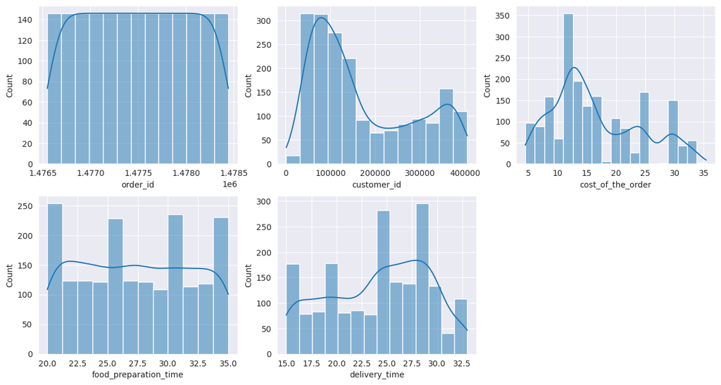

```python
# Write the code here

#Exploratory Data Analysis - Univariate Analysis

#Let's start by exploring numerical columns though Histograms:

numeric_columns = ['order_id','customer_id', 'cost_of_the_order', 'food_preparation_time', 'delivery_time']
plt.figure(figsize=(15, 12))

for i, variable in enumerate(numeric_columns):
  sns.set_style("darkgrid")
  plt.subplot(3, 3, i+1)
  sns.histplot(data =df, x = df[variable], kde=True)
plt.show()
```

```python
df['order_id'].nunique()
```

```
1898
```

#### Histogram observations: As expected, the histogram for order_id is not meaningful due to its uniqueness per record. Similarly, customer_id is numeric but categorical in nature, making a histogram to perform as a countplot. For cost, most orders costs around $12. Food preparation times concentrate at 20, 25, 30, and 35 minutes; while delivery times peak at approximately around 25 and 30 minutes.

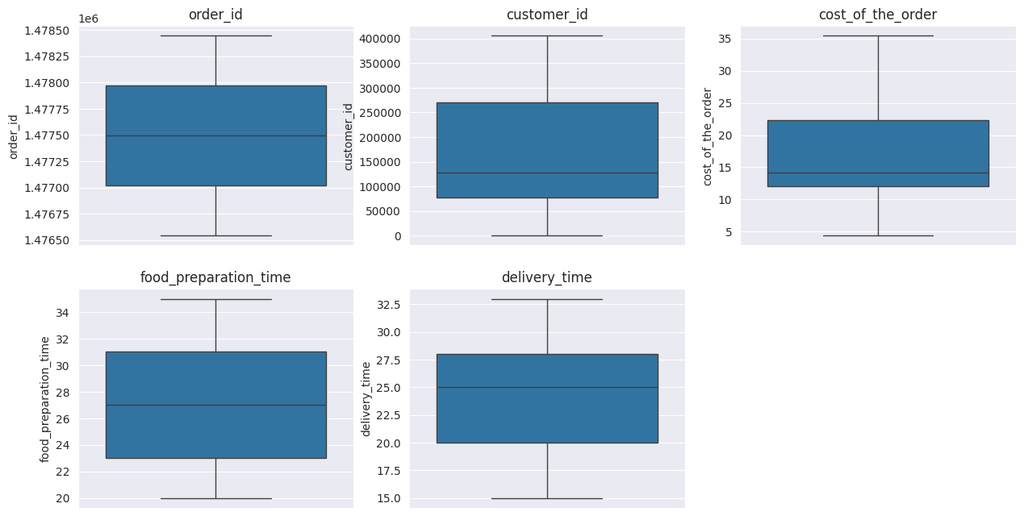

```python
#Creating boxplots on numerical variables:

numeric_columns = ['order_id','customer_id', 'cost_of_the_order', 'food_preparation_time', 'delivery_time']
plt.figure(figsize=(15, 12))

for i, variable in enumerate(numeric_columns):
  sns.set_style("darkgrid")
  plt.subplot(3, 3, i+1)
  sns.boxplot(data =df, y = df[variable], whis=1.5)
  plt.title(variable)
plt.show()
```

#### Boxplot observations: The boxplots above show a median order cost of approximately 14 dollars, with 50% of orders priced between 12 and 23 dollars. Food preparation times have a median of 27 minutes, with half of orders taking 23 to 31 minutes. Delivery times have a median of 25 minutes, with half completed in 20-28 minutes. No outliers were observed in the numerical variables.

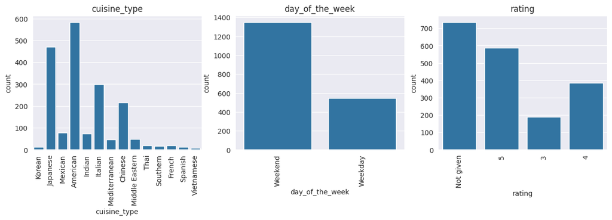

```python
#Lets create countplots to explore the categorical variables

#sns.countplot(data=df, x='booking_status');

categorical_columns =  df.dtypes[df.dtypes ==  'object'].index
categorical_columns =  categorical_columns.drop(['restaurant_name'])
plt.figure(figsize=(15, 12))

for i, var in enumerate(categorical_columns):
  sns.set_style("darkgrid")
  plt.subplot(3, 3, i+1)
  sns.countplot(data =df, x = df[var])
  plt.xticks(rotation=90)
  plt.title(var)
plt.show()
```

```python
#Let's drill down a bit more on the restaurant_name variable:

#Calculate value counts and get the top 15 categories

top15 = df['restaurant_name'].value_counts()[0:15]
top15.dtype

top_15 = pd.DataFrame(top15)

top_15.reset_index(inplace=True)
top_15.columns = ['restaurant_name', 'count']

top_15
```

|  | restaurant_name | count |
| --- | --- | --- |
| 0 | Shake Shack | 219 |
| 1 | The Meatball Shop | 132 |
| 2 | Blue Ribbon Sushi | 119 |
| 3 | Blue Ribbon Fried Chicken | 96 |
| 4 | Parm | 68 |
| 5 | RedFarm Broadway | 59 |
| 6 | RedFarm Hudson | 55 |
| 7 | TAO | 49 |
| 8 | Han Dynasty | 46 |
| 9 | Blue Ribbon Sushi Bar & Grill | 44 |
| 10 | Nobu Next Door | 42 |
| 11 | Sushi of Gari 46 | 37 |
| 12 | Rubirosa | 37 |
| 13 | Momoya | 30 |
| 14 | Five Guys Burgers and Fries | 29 |

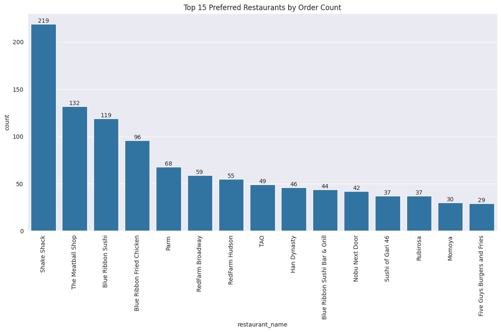

```python
#Creating plots with seaborn as Plotly does not appear in .html notebook

plt.figure(figsize=(12, 8))
ax = sns.barplot(data=top_15, x='restaurant_name', y='count')
plt.xticks(rotation=90)

# Add count labels on top of bars
for p in ax.patches:
    height = p.get_height()
    ax.annotate(f'{int(height)}', (p.get_x() + p.get_width() / 2., height),
                ha='center', va='bottom')

plt.title('Top 15 Preferred Restaurants by Order Count')
plt.tight_layout()
plt.show()
```

### **Question 7**: Which are the top 5 restaurants in terms of the number of orders received? [1 mark]

```python
# Write the code here

#Top 5 restaurants in terms of the numbers of orders received:

top5 = df['restaurant_name'].value_counts(normalize=True)[0:5]
top5.dtype

top_5 = pd.DataFrame(top5)

top_5.reset_index(inplace=True)
top_5.columns = ['restaurant_name', 'count']

top_5
```

|  | restaurant_name | count |
| --- | --- | --- |
| 0 | Shake Shack | 0.115385 |
| 1 | The Meatball Shop | 0.069547 |
| 2 | Blue Ribbon Sushi | 0.062698 |
| 3 | Blue Ribbon Fried Chicken | 0.050580 |
| 4 | Parm | 0.035827 |

#### Observations: The bar graph highlights the top five restaurants by order volume: Shake Shack, The Meatball Shop, Blue Ribbon Sushi, Blue Ribbon Fried Chicken, and Parm. Shake Shack alone accounts for approximately 11% of total orders, reinforcing the strong customer preference for American cuisine within the dataset. The prominence of these restaurants indicates a concentrated demand among a few key players, which could be leveraged for targeted promotions or partnership opportunities to further boost customer engagement and revenue.

### **Question 8**: Which is the most popular cuisine on weekends? [1 mark]

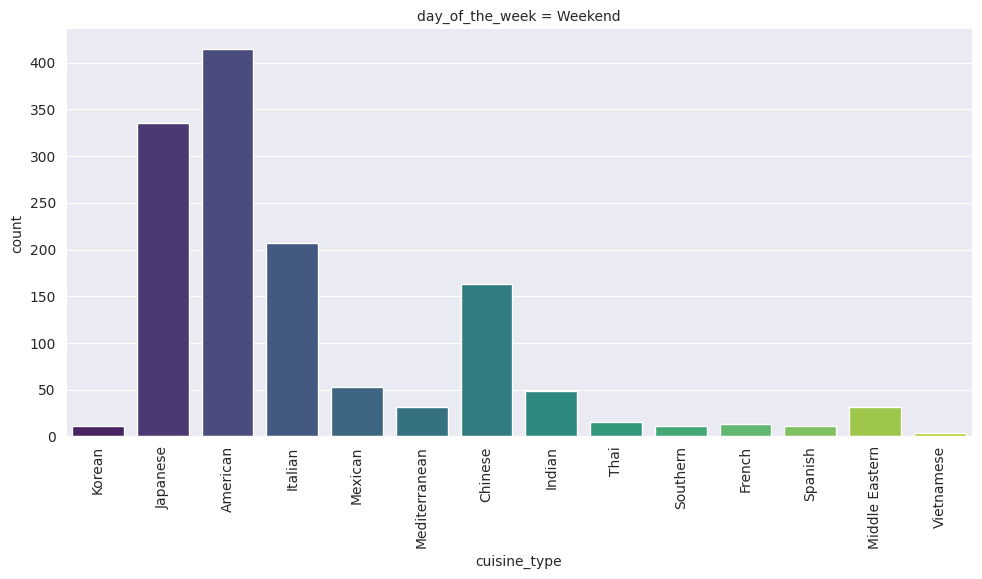

```python
# Write the code here

#sns.countplot(data=df[df['day_of_the_week'] == 'Weekend'], x='cuisine_type');
#plt.xticks(rotation=90)
#plt.show()

plt.figure(figsize=(15,12))
sns.set_style("darkgrid")
sns.catplot(data=df[df['day_of_the_week'] == 'Weekend'], x="cuisine_type", hue= 'cuisine_type', col="day_of_the_week", kind='count', palette = 'viridis', height=5, aspect=2)
plt.xticks(rotation=90)
plt.show()
```

#### Observations: The most popular cuisine on weekends are American, Japanase, Italian and Chinese foods.

### **Question 9**: What percentage of the orders cost more than 20 dollars? [2 marks]

```python
# Write the code here

df['price_cat'] = pd.cut(df['cost_of_the_order'], bins=[0,10,20,36], labels=['Below 10', 'Between 10 and 20', 'Aboove 20'], right=False)

df['price_cat']. value_counts(normalize = True)

#df[df['cost_of_the_order'] > 20].shape[0]/df.shape[0]
```

| price_cat | proportion |
| --- | --- |
| Between 10 and 20 | 0.500000 |
| Aboove 20 | 0.292413 |
| Below 10 | 0.207587 |

**dtype:** float64

#### Observations: About 29.24% of the orders cost more than $20.

### **Question 10**: What is the mean order delivery time? [1 mark]

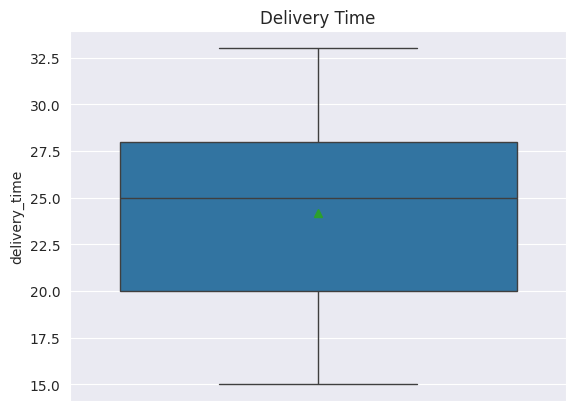

```
Mean order delivery time: 24.161749209694417
```

```python
# Write the code here

sns.set_style("darkgrid")
sns.boxplot(data =df, y = df['delivery_time'], showmeans=True)
plt.title('Delivery Time')
plt.show()

print('Mean order delivery time:', df['delivery_time'].mean())
```

#### Observations: The mean order delivery time is 24.16 minutes.

### **Question 11:** The company has decided to give 20% discount vouchers to the top 3 most frequent customers. Find the IDs of these customers and the number of orders they placed. [1 mark]

```python
# Write the code here
#Creating a dataframe to store the most frequent customers

top3 = df['customer_id'].value_counts()[0:3]
top3.dtype

top_3 = pd.DataFrame(top3)

top_3.reset_index(inplace=True)
top_3.columns = ['customer_id', 'count']



top_3['customer_id'] = top_3['customer_id'].astype(str)

top_3
```

|  | customer_id | count |
| --- | --- | --- |
| 0 | 52832 | 13 |
| 1 | 47440 | 10 |
| 2 | 83287 | 9 |

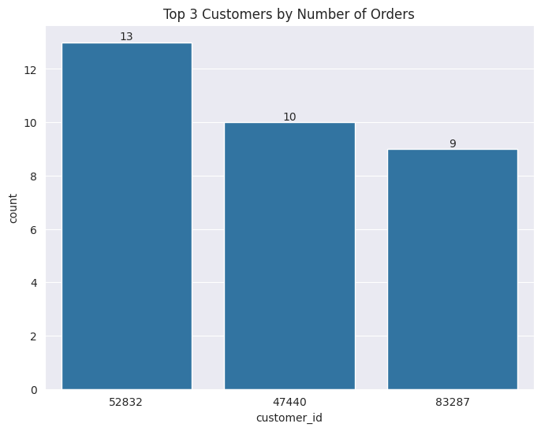

```python
#Bar plot on the top 3 most frequent customers:
plt.figure(figsize=(8, 6))

ax = sns.barplot(data=top_3, x='customer_id', y='count')

# Add count labels on top of bars
for p in ax.patches:
    height = p.get_height()
    ax.annotate(f'{int(height)}', (p.get_x() + p.get_width() / 2., height),
                ha='center', va='bottom')

# Set title and axis labels
plt.title('Top 3 Customers by Number of Orders')
plt.show()
```

### **Question 12**: Perform a multivariate analysis to explore relationships between the important variables in the dataset. (It is a good idea to explore relations between numerical variables as well as relations between numerical and categorical variables) [10 marks]

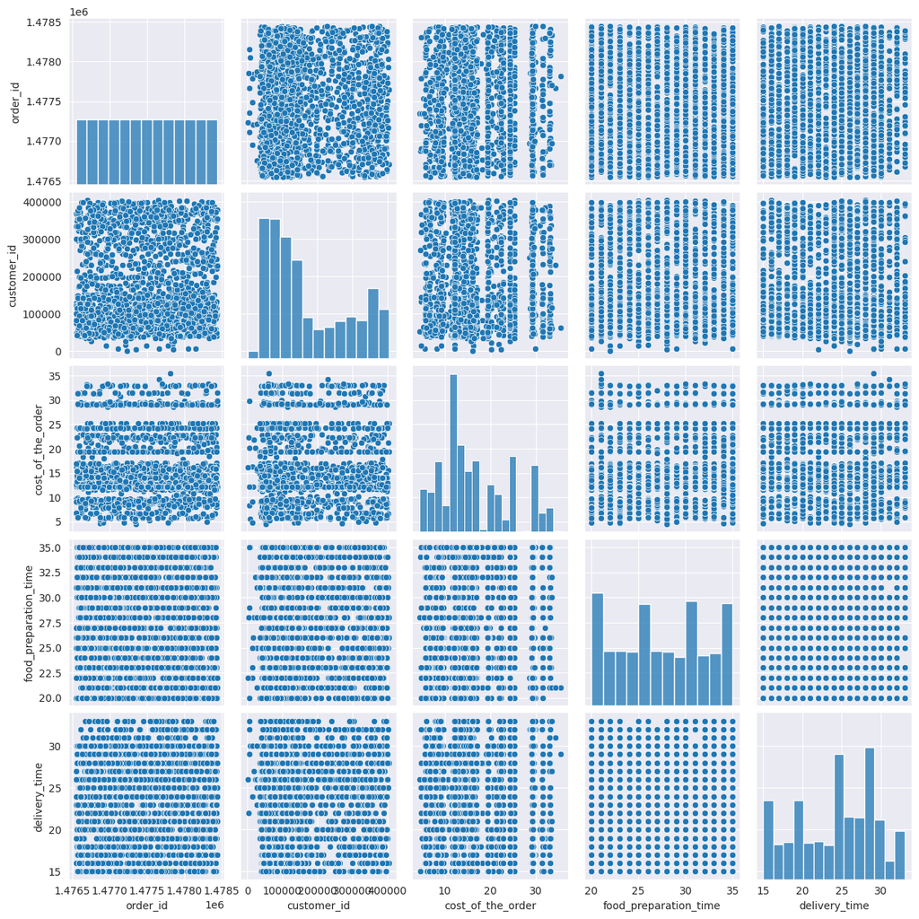

```python
# Write the code here
# Let's create a pairplot to explore the relationship between two numeric variables for each pair of columns in the dataset

sns.pairplot(data=df, vars=['order_id', 'customer_id', 'cost_of_the_order', 'food_preparation_time', 'delivery_time']);
```

#### By creating a pairplot to explore the relationship between numerical variables, no positive or negative relationships can be clearly identified. Let's create a correlation matrix for the numerical variables and see if any further insights are revealed.

```python
df.corr(numeric_only=True)
```

|  | order_id | customer_id | cost_of_the_order | food_preparation_time | delivery_time |
| --- | --- | --- | --- | --- | --- |
| order_id | 1.000000 | -0.013960 | 0.021171 | -0.007026 | 0.009690 |
| customer_id | -0.013960 | 1.000000 | -0.001322 | -0.030330 | -0.009885 |
| cost_of_the_order | 0.021171 | -0.001322 | 1.000000 | 0.041527 | -0.029949 |
| food_preparation_time | -0.007026 | -0.030330 | 0.041527 | 1.000000 | 0.011094 |
| delivery_time | 0.009690 | -0.009885 | -0.029949 | 0.011094 | 1.000000 |

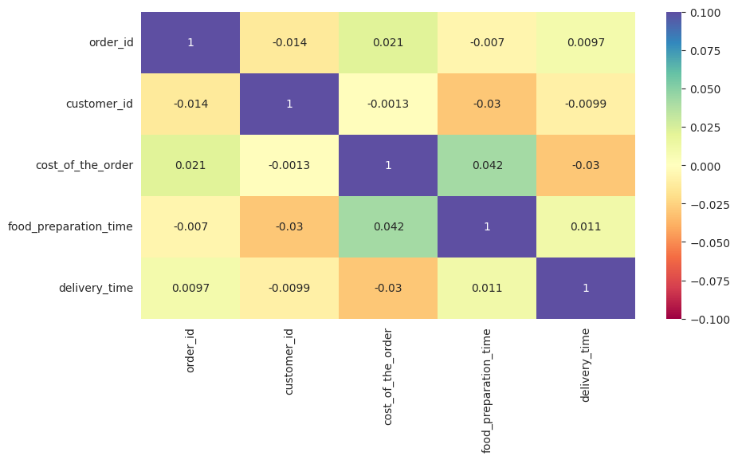

```python
#Plot a correlation matrix:

plt.figure(figsize=(10,5))
sns.heatmap(df.corr(numeric_only=True), annot = True, cmap='Spectral', vmin = -0.1, vmax = 0.1)
plt.show()
```

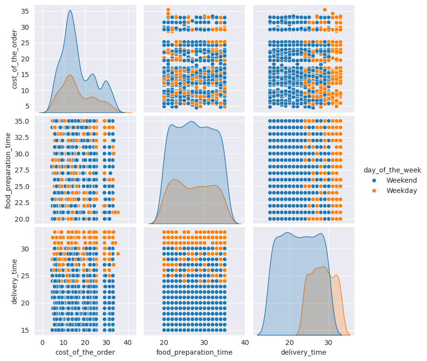

```python
#Let's explore the numerical variables and see how they compare on weekdays vs. on weekends:

sns.pairplot(data=df, vars=['cost_of_the_order', 'food_preparation_time', 'delivery_time'], hue='day_of_the_week');
```

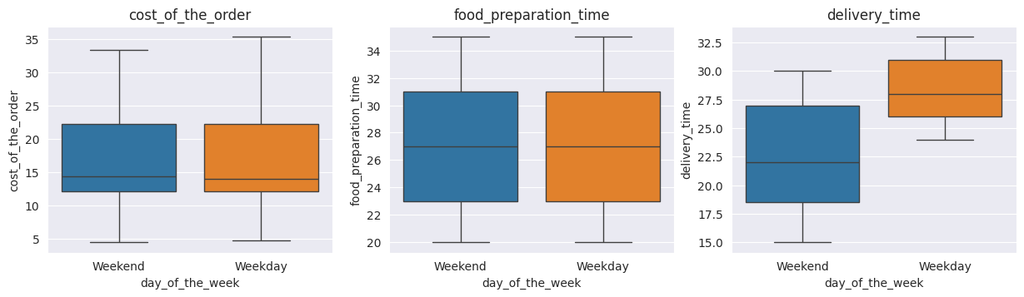

```python
#Creating boxplots on numerical variables and categorical:

numeric_columns = ['cost_of_the_order', 'food_preparation_time', 'delivery_time']
plt.figure(figsize=(15, 12))

for i, variable in enumerate(numeric_columns):
  sns.set_style("darkgrid")
  plt.subplot(3, 3, i+1)
  sns.boxplot(data =df, x = df['day_of_the_week'], y = df[variable], hue=df['day_of_the_week'])
  plt.title(variable)
plt.show()
```

#### Observations: The plots above show that order costs, and preparation time does not vary much for week days or weekends, although considerably more orders are made on weekends. Surprisingly, the delivery time is higher for weekdays.

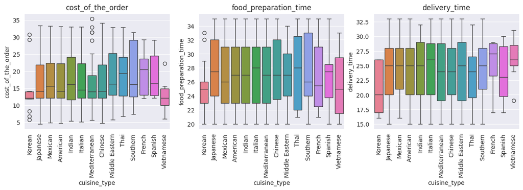

```python
#Creating boxplots on numerical variables and categorical:

numeric_columns = ['cost_of_the_order', 'food_preparation_time', 'delivery_time']
plt.figure(figsize=(15, 12))

for i, variable in enumerate(numeric_columns):
  sns.set_style("darkgrid")
  plt.subplot(3, 3, i+1)
  sns.boxplot(data =df, x = df['cuisine_type'], y = df[variable], hue=df['cuisine_type'])
  plt.title(variable)
  plt.xticks(rotation=90)
plt.show()
```

### **Question 13:** The company wants to provide a promotional offer in the advertisement of the restaurants. The condition to get the offer is that the restaurants must have a rating count of more than 50 and the average rating should be greater than 4. Find the restaurants fulfilling the criteria to get the promotional offer. [3 marks]

```python
# Write the code here

df_clean = df.copy()

#Lets replace "missing" and "inf" with NaN:

df_clean['rating'] = df['rating'].replace(['Not given'], np.nan)
```

```python
df_clean['rating'] = df_clean['rating'].astype('Int64')

df_clean['rating'].unique()
```

```
<IntegerArray>
[<NA>, 5, 3, 4]
Length: 4, dtype: Int64
```

```python
rest_count = df_clean.groupby(['restaurant_name'])['rating'].count().reset_index()
rest_count.columns = ['restaurant_name', 'rating_count']
rest_count.sort_values(by='rating_count', ascending=False)

#rest_count[rest_count['rating_count'] > 50]
```

|  | restaurant_name | rating_count |
| --- | --- | --- |
| 136 | Shake Shack | 133 |
| 153 | The Meatball Shop | 84 |
| 21 | Blue Ribbon Sushi | 73 |
| 20 | Blue Ribbon Fried Chicken | 64 |
| 121 | RedFarm Broadway | 41 |
| ... | ... | ... |
| 123 | Rohm Thai | 0 |
| 139 | Spice Thai | 0 |
| 117 | Posto | 0 |
| 147 | Tarallucci e Vino Restaurant | 0 |
| 164 | Wa Jeal | 0 |

178 rows × 2 columns

```python
rest_rate = df_clean.groupby(['restaurant_name'])['rating'].mean().reset_index()
rest_rate.columns = ['restaurant_name', 'rating_mean']
#rest_count.sort_values(by='rating_count', ascending=False)
rest_rate[rest_rate['rating_mean'] > 4].sort_values(by='rating_mean', ascending=False)
```

|  | restaurant_name | rating_mean |
| --- | --- | --- |
| 0 | 'wichcraft | 5.0 |
| 3 | 67 Burger | 5.0 |
| 8 | Asuka Sushi | 5.0 |
| 7 | Anjappar Chettinad | 5.0 |
| 15 | Bhatti Indian Grill | 5.0 |
| ... | ... | ... |
| 30 | Cafe Mogador | 4.153846 |
| 176 | ilili Restaurant | 4.153846 |
| 109 | Parm | 4.128205 |
| 125 | Rubirosa | 4.125 |
| 13 | Bareburger | 4.058824 |

110 rows × 2 columns

```python
#pd.merge(data_cust,data_cust_new,how='outer',on='customerID')

top_rest = pd.merge(rest_count,rest_rate,how='outer',on='restaurant_name').sort_values(by='rating_count', ascending=False).reset_index(drop=True)

top_rest = pd.DataFrame(top_rest)
```

```python
top_rest = top_rest[(top_rest['rating_count'] > 50) & (top_rest['rating_mean'] > 4)]

top_rest
```

|  | restaurant_name | rating_count | rating_mean |
| --- | --- | --- | --- |
| 0 | Shake Shack | 133 | 4.278195 |
| 1 | The Meatball Shop | 84 | 4.511905 |
| 2 | Blue Ribbon Sushi | 73 | 4.219178 |
| 3 | Blue Ribbon Fried Chicken | 64 | 4.328125 |

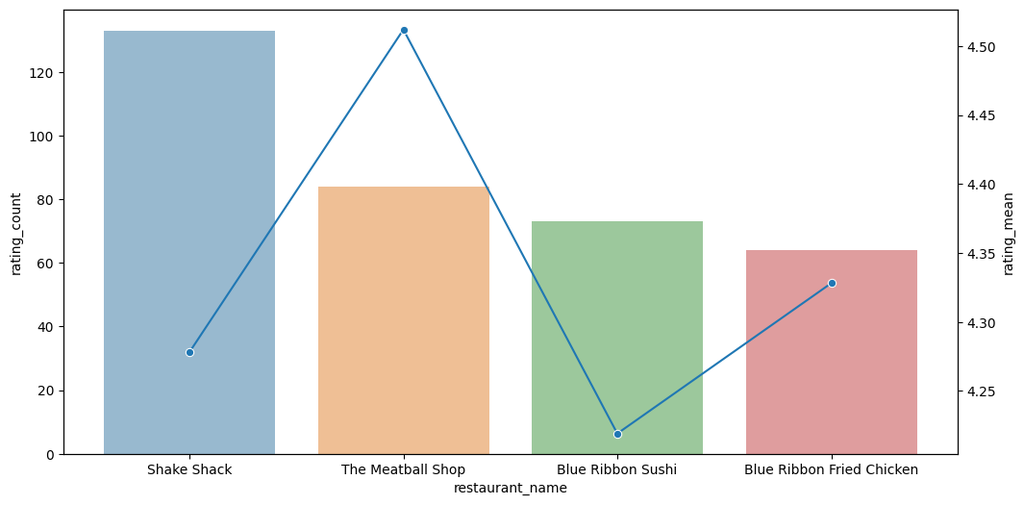

```python
#Creating a bar plot with a line plot to be able to visualize the restaurant count and average restaurant ratings on the same graph:
import matplotlib
import matplotlib.pyplot as plt
import seaborn as sns
#sns.catplot(data=top_rest, x="restaurant_name", y="rating_count", kind='bar');

matplotlib.rc_file_defaults()


fig, ax1 = plt.subplots(figsize=(12,6))

sns.barplot(data = top_rest, x='restaurant_name', y='rating_count', alpha=0.5, ax=ax1, hue='restaurant_name')
ax2 = ax1.twinx()
sns.lineplot(data = top_rest['rating_mean'], marker='o', sort = False, ax=ax2)
```

#### Observations: The graph above demonstrates that the restaurants fulfilling the criteria to get the promotional offer are Shake Shack, The Meatball Shop, Blue Ribbon Sushi, and Blue Ribbon Fried Chicken.

### **Question 14:** The company charges the restaurant 25% on the orders having cost greater than 20 dollars and 15% on the orders having cost greater than 5 dollars. Find the net revenue generated by the company across all orders. [3 marks]

```python
#Creating a function to define the revenue condition:
def rev(r):
    if r > 20:
        r = r * 0.25
    elif 5 < r <= 20:
        r = r * 0.15
    else:
        r = 0
    return r
```

```python
#Applying the revenue function on the order costs field to create a new column with revenue values.
df['revenue'] = df['cost_of_the_order'].apply(rev)

df.head()
```

|  | order_id | customer_id | restaurant_name | cuisine_type | cost_of_the_order | day_of_the_week | rating | food_preparation_time | delivery_time | price_cat | revenue |
| --- | --- | --- | --- | --- | --- | --- | --- | --- | --- | --- | --- |
| 0 | 1477147 | 337525 | Hangawi | Korean | 30.75 | Weekend | Not given | 25 | 20 | Aboove 20 | 7.6875 |
| 1 | 1477685 | 358141 | Blue Ribbon Sushi Izakaya | Japanese | 12.08 | Weekend | Not given | 25 | 23 | Between 10 and 20 | 1.8120 |
| 2 | 1477070 | 66393 | Cafe Habana | Mexican | 12.23 | Weekday | 5 | 23 | 28 | Between 10 and 20 | 1.8345 |
| 3 | 1477334 | 106968 | Blue Ribbon Fried Chicken | American | 29.20 | Weekend | 3 | 25 | 15 | Aboove 20 | 7.3000 |
| 4 | 1478249 | 76942 | Dirty Bird to Go | American | 11.59 | Weekday | 4 | 25 | 24 | Between 10 and 20 | 1.7385 |

```python
df['revenue'] = round(df['revenue'], 2)

df.describe()
```

|  | order_id | customer_id | cost_of_the_order | food_preparation_time | delivery_time | revenue |
| --- | --- | --- | --- | --- | --- | --- |
| count | 1.898000e+03 | 1898.000000 | 1898.000000 | 1898.000000 | 1898.000000 | 1898.000000 |
| mean | 1.477496e+06 | 171168.478398 | 16.498851 | 27.371970 | 24.161749 | 3.248894 |
| std | 5.480497e+02 | 113698.139743 | 7.483812 | 4.632481 | 4.972637 | 2.295623 |
| min | 1.476547e+06 | 1311.000000 | 4.470000 | 20.000000 | 15.000000 | 0.000000 |
| 25% | 1.477021e+06 | 77787.750000 | 12.080000 | 23.000000 | 20.000000 | 1.810000 |
| 50% | 1.477496e+06 | 128600.000000 | 14.140000 | 27.000000 | 25.000000 | 2.120000 |
| 75% | 1.477970e+06 | 270525.000000 | 22.297500 | 31.000000 | 28.000000 | 5.575000 |
| max | 1.478444e+06 | 405334.000000 | 35.410000 | 35.000000 | 33.000000 | 8.850000 |

```python
# Finding the net revenue generated by the company across all orders.
print('Net Revenue:', round(df['revenue'].sum(),2))
```

```
Net Revenue: 6166.4
```

#### Observations: The Net Revenue generated by the company accross all orders is $6166.4.

### **Question 15:** The company wants to analyze the total time required to deliver the food. What percentage of orders take more than 60 minutes to get delivered from the time the order is placed? (The food has to be prepared and then delivered.) [2 marks]

```python
# Write the code here

df['total_delivery_time'] = df['food_preparation_time'] + df['delivery_time']

df.head()
```

|  | order_id | customer_id | restaurant_name | cuisine_type | cost_of_the_order | day_of_the_week | rating | food_preparation_time | delivery_time | price_cat | revenue | total_delivery_time |
| --- | --- | --- | --- | --- | --- | --- | --- | --- | --- | --- | --- | --- |
| 0 | 1477147 | 337525 | Hangawi | Korean | 30.75 | Weekend | Not given | 25 | 20 | Aboove 20 | 7.69 | 45 |
| 1 | 1477685 | 358141 | Blue Ribbon Sushi Izakaya | Japanese | 12.08 | Weekend | Not given | 25 | 23 | Between 10 and 20 | 1.81 | 48 |
| 2 | 1477070 | 66393 | Cafe Habana | Mexican | 12.23 | Weekday | 5 | 23 | 28 | Between 10 and 20 | 1.83 | 51 |
| 3 | 1477334 | 106968 | Blue Ribbon Fried Chicken | American | 29.20 | Weekend | 3 | 25 | 15 | Aboove 20 | 7.30 | 40 |
| 4 | 1478249 | 76942 | Dirty Bird to Go | American | 11.59 | Weekday | 4 | 25 | 24 | Between 10 and 20 | 1.74 | 49 |

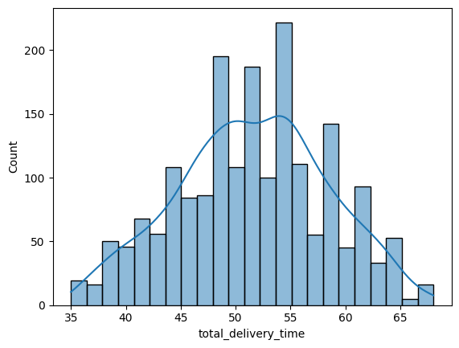

```
% of orders with more than 60 minutes to prepare: 10.537407797681771
```

```python
#Creating a histogram to visualize the numerical variable created for total_delivery_time
sns.histplot(data=df, x='total_delivery_time', kde=True)
plt.show()

#Calculation to verify the percentage of orders that takes more than 60 minutes to prepare
print('% of orders with more than 60 minutes to prepare:', (df[df['total_delivery_time'] > 60].shape[0]/df.shape[0]) * 100)
```

#### Observations: 10.54% of the orders take more than 60 minutes to get delivered from the time the order is placed.

### **Question 16:** The company wants to analyze the delivery time of the orders on weekdays and weekends. How does the mean delivery time vary during weekdays and weekends? [2 marks]

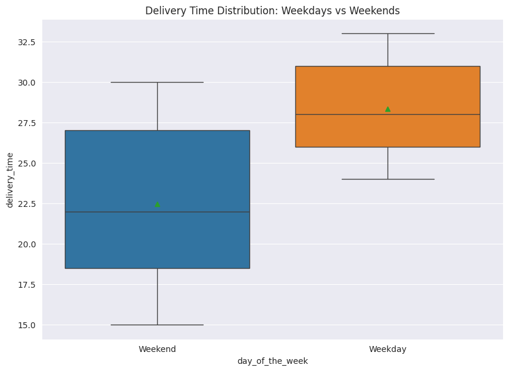

```python
#This plot was previously represented by a plotly graph
plt.figure(figsize=(10, 7))

# Create boxplot with hue color by day_of_the_week
sns.set_style("darkgrid")
ax = sns.boxplot(x='day_of_the_week', y='delivery_time', data=df, hue = 'day_of_the_week', showmeans=True)

plt.title('Delivery Time Distribution: Weekdays vs Weekends')
plt.show()
```

```python
#Checking mean values for delivery times on weekends and weekdays.

df.groupby(['day_of_the_week'])['delivery_time'].mean()
```

| day_of_the_week | delivery_time |
| --- | --- |
| Weekday | 28.340037 |
| Weekend | 22.470022 |

**dtype:** float64

#### Observation: Interestingly, the analysis reveals that delivery times are longer on weekdays compared to weekends. The average delivery time on weekdays is approximately 28.34 minutes, whereas on weekends it decreases to around 22.5 minutes. This counterintuitive pattern may be influenced by factors such as higher traffic congestion during weekday peak hours, differing order volumes, or delivery workforce availability.

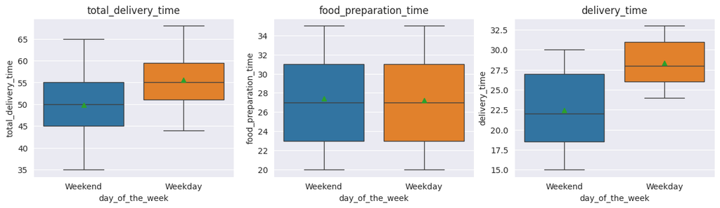

```python
#Creating boxplots to compare time amount:

numeric_columns = ['total_delivery_time', 'food_preparation_time', 'delivery_time']
plt.figure(figsize=(15, 12))

for i, variable in enumerate(numeric_columns):
  sns.set_style("darkgrid")
  plt.subplot(3, 3, i+1)
  sns.boxplot(data =df, x = df['day_of_the_week'], y = df[variable], hue=df['day_of_the_week'], showmeans = True)
  plt.title(variable)
plt.show()
```

### Conclusion and Recommendations: The boxplots reveal a notable variation in delivery times between weekdays and weekends, with weekday delivery times averaging about 6 minutes longer. Meanwhile, food preparation times remain fairly consistent across both periods. This suggests that the primary driver of total customer wait time differences is the delivery phase, likely impacted by factors such as increased traffic congestion on weekdays. Given this insight, it would be beneficial to inform customers about the potential for longer wait times during weekdays. Additionally, understanding these underlying causes could help optimize delivery scheduling and resource allocation to reduce weekday delivery times and improve customer satisfaction.

### **Question 17:** What are your conclusions from the analysis? What recommendations would you like to share to help improve the business? (You can use cuisine type and feedback ratings to drive your business recommendations.) [6 marks]

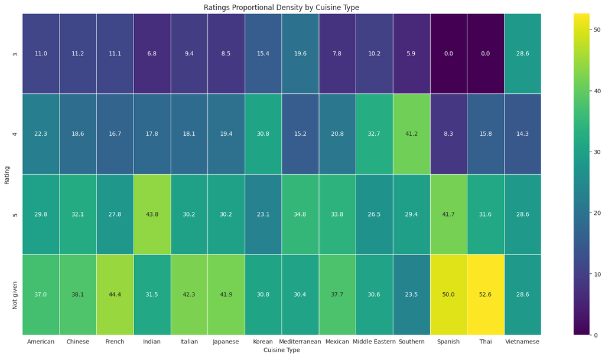

```python
# Creating the grouped count matrix
df_hm = df.groupby(['rating', 'cuisine_type'])['rating'].count().unstack(fill_value=0)

# Converting counts to proportions per cuisine type
df_hm_prop = df_hm.div(df_hm.sum(axis=0), axis=1) * 100

#Plotting the map to show proportional rating numbers
plt.figure(figsize=(20, 10))
sns.heatmap(df_hm_prop, fmt=".1f", cmap='viridis', linewidths=.5, annot=True)
plt.title("Ratings Proportional Density by Cuisine Type")
plt.xlabel("Cuisine Type")
plt.ylabel("Rating")
plt.show()
```

```python
#Lets replace "Not given" with NaN:

df['rating'] = df['rating'].replace(['Not given'], np.nan)
```

```python
#changing the data type to int:

df['rating'] = df['rating'].astype('Int64')
```

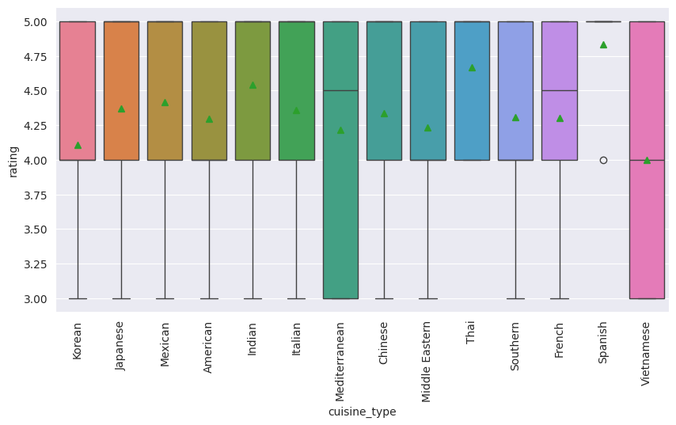

```python
#Lastly, let's check how rating varies across the different cuisines
plt.figure(figsize=(10,5))
sns.boxplot(data=df,x='cuisine_type',y='rating', hue='cuisine_type', showmeans=True)
plt.xticks(rotation=90)
plt.show()
```

### Conclusions:

The data analysis on the FoodHub dataset reveals clear patterns in customer preferences, operational performance, and satisfaction. American, Japanese, Italian, and Chinese cuisines dominate order volumes, with Shake Shack alone accounting for approximately 11% of all orders, demonstrating the strong demand for American cuisine. Nearly 29.24% of orders cost more than $20, highlighting a significant segment of customers willing to spend on premium meals.

Operationally, food preparation time averages about 27.4 minutes with a range between 20 and 35 minutes, remaining consistent across weekdays and weekends. However, delivery time emerges as the critical factor affecting total wait times: the mean delivery time is 24.16 minutes overall, but varies significantly between weekdays and weekends, averaging 28.34 minutes on weekdays compared to 22.5 minutes on weekends. Notably, 10.54% of orders take over 60 minutes to be delivered, from the time an order is made, suggesting delivery inefficiencies impacting customer experience.